# Simple Comparative Experiments

Chapter 2 begins with several methods of visualization that are easily reproducible within R. These visualizations are based on the data in Table 2.1 which records the results of an experiment where a researcher was comparing the strength of a new mortar formulation to that of the original unmodified formulation.

| ModifiedMortar | UnmodifiedMortar |
| --- | --- |
| 16.85 | 16.62 |
| 16.40 | 16.75 |
| 17.21 | 17.37 |
| 16.35 | 17.12 |
| 16.52 | 16.98 |
| 17.04 | 16.87 |
| 16.96 | 17.34 |
| 17.15 | 17.02 |
| 16.59 | 17.08 |
| 16.57 | 17.27 |

In R, the object `Table2.1` is a `data.frame` that has a column `ModifiedMortar` and a column `UnmodifiedMortar`. The structure of this object is given below.

```r
str(Table2.1)
# 'data.frame': 10 obs. of  2 variables:
#  $ ModifiedMortar  : num  16.9 16.4 17.2 16.4 16.5 ...
#  $ UnmodifiedMortar: num  16.6 16.8 17.4 17.1 17 ...
```

We can use the R command `attach` to take the columns of the data.frame and make them accessible by name (e.g. we can use `ModifiedMortar` instead of `Table2.1$ModifiedMortar`).

```r
attach(Table2.1)
all(ModifiedMortar == Table2.1$ModifiedMortar)
# [1] TRUE
```

When we’re all done with the data we should call `detach(Table2.1)`.

With the data loaded let’s move on to some of the visualizations in Chapter 2.

# Visualizations

We begin with the dot plot of Figure 2.1.

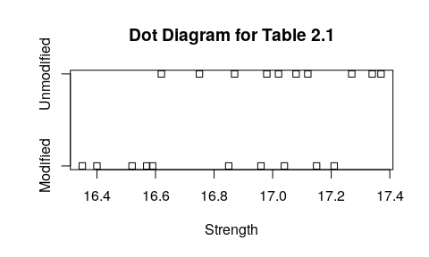

```r
stripchart(
    list(
        'Modified'=ModifiedMortar,
        'Unmodified'=UnmodifiedMortar
    ),
    main="Dot Diagram for Table 2.1",
    xlab='Strength'
)
```

The graph seems to suggest that the modified formulation has a lower average strength than that of the unmodified formulation.

Figure 2.2 in the text is a histogram of 200 observations of metal recovery, for which no data is given. Though we lack the full data set, let’s construct a histogram of the 20 data points from combining the modified and unmodified mortar formulation data.

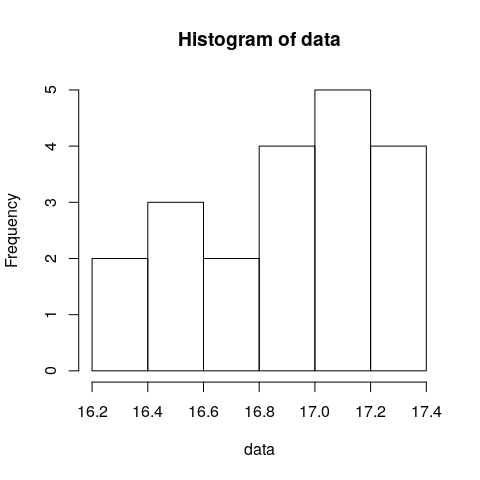

```r
data <- c(ModifiedMortar, UnmodifiedMortar)
hist(data)
```

Though it was easy to construct, the histogram is not giving us a lot of information in this case due to the fact that we have such a small amount of data.

The dot plot of Figure 2.1 can become very difficult to interpret when the number of observations becomes large. In these cases we can use a box plot which is constructed based on summary statistics of the data. The box plots of Figure 2.3 are presented next.

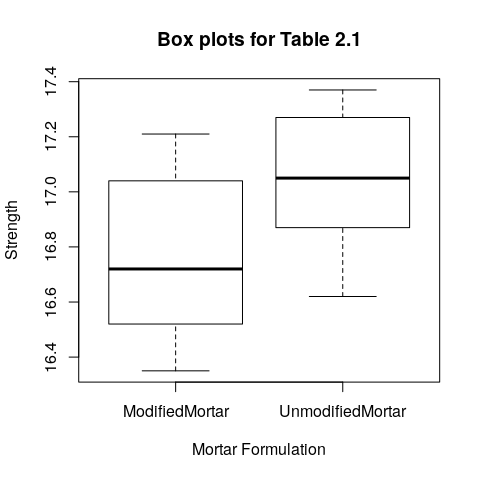

```r
bp.returned <- boxplot(
    Table2.1,
    main="Box plots for Table 2.1",
    xlab='Mortar Formulation',
    ylab='Strength'
)
```

This plot also suggests that the modified mortar formulation has a lower mean strength than the unmodified formulation. Note that I assigned the return value from the `boxplot` function to a variable `bp.returned`. Several graphics functions return data used in the graphical construction. The `boxplot` function returns the summary statistics used to create the plots.

```r
print(bp.returned)
# $stats
#       [,1]  [,2]
# [1,] 16.35 16.62
# [2,] 16.52 16.87
# [3,] 16.72 17.05
# [4,] 17.04 17.27
# [5,] 17.21 17.37
#
# $n
# [1] 10 10
#
# $conf
#          [,1]     [,2]
# [1,] 16.46019 16.85014
# [2,] 16.97981 17.24986
#
# $out
# numeric(0)
#
# $group
# numeric(0)
#
# $names
# [1] "ModifiedMortar"   "UnmodifiedMortar"
```

# Statistics and Distributions

The box plot was a nice way to illustrate the distribution of our data, but we could also use the `summary` function to get summary statistics.

```r
summary(Table2.1)
#  ModifiedMortar  UnmodifiedMortar
#  Min.   :16.35   Min.   :16.62
#  1st Qu.:16.53   1st Qu.:16.90
#  Median :16.72   Median :17.05
#  Mean   :16.76   Mean   :17.04
#  3rd Qu.:17.02   3rd Qu.:17.23
#  Max.   :17.21   Max.   :17.37
```

Other statistics of interest such as standard deviation (or variance) and empirical quantiles are easy to collect. I’ll define a new `data.frame` with some statistics.

```r
dstat <- data.frame(
    'Modified'=c(
        mean(ModifiedMortar),
        var(ModifiedMortar),
        sd(ModifiedMortar),
        length(ModifiedMortar)
    ),
    'Unmodified'=c(
        mean(UnmodifiedMortar),
        var(UnmodifiedMortar),
        sd(UnmodifiedMortar),
        length(UnmodifiedMortar)
    ),
    row.names=c('mean', 'variance', 'sd','obs')
)
```

The `dstat` object then contains the following.

|  | Modified | Unmodified |
| --- | --- | --- |
| mean | 16.7640000 | 17.0420000 |
| variance | 0.1001378 | 0.0614622 |
| sd | 0.3164455 | 0.2479158 |
| obs | 10.0000000 | 10.0000000 |

If we want to create a pooled estimator of variance $S_p^2$ we can do so manually.

```r
n1 <- dstat['obs','Modified']
n2 <- dstat['obs','Unmodified']
S1sq <- dstat['var','Modified']
S2sq <- dstat['var','Unmodified']
pooled.var <- ((n1 - 1) * S1sq + (n2 - 1) * S2sq) / (n1 + n2 - 2)
print(pooled.var)
# [1] 0.0808
```

This calculation matches that of the text. Similarly, we can create the $t$-statistic to test the hypotheses
$$H_0: \mu_\text{Modified} = \mu_\text{Unmodified}
\quad\text{vs.}\quad
H_1: \mu_\text{Modified} \ne \mu_\text{Unmodified}~.$$

```r
ybar1 <- dstat['mean', 'Modified']
ybar2 <- dstat['mean', 'Unmodified']
t0 <- (ybar1 - ybar2) / sqrt(pooled.var * (1/n1 + 1/n2))
print(t0)
# [1] -2.186876
```

We can evaluate the statistic in two ways. First, we can use the critical region approach and find $t_{0.025, 18}$ using the `qt` function. Note that in R, all of the quantile functions give the area to the left (the lower area), but this text and many others take the symbol $t_{\alpha, n}$ to mean the critical point where the area *to the right* is $\alpha$. To adjust for this we give the argument `lower.tail=FALSE`.

```r
critical.t <- qt(0.025, 18, lower.tail=FALSE)
print(critical.t)
# [1] 2.100922
```

Because $|t_0| > t_{0.025, 18}$ we would reject $H_0$. The other option is to find the $p$-value using the $pt$ function.

```r
2 * (1 - pt(abs(t0), 18))
# [1] 0.04219672
```

Since the $p$-value was less that $0.05$ we would again reject $H_0$.

That was a lot of typing to just perform a two-sample $t$-test! A shorter path would be to use R’s `t.test` function. This requires us to reshape our data into a column for strength and a column that indicates if the observation was for the modified or unmodified formulation.

```r
df <- data.frame(
    'Strength'=c(ModifiedMortar, UnmodifiedMortar),
    'Mortar'=factor(c(rep('Modified', 10), rep('Unmodified', 10)))
)
t.test(Strength ~ Mortar, data=df, paired=FALSE, var.equal=TRUE)
#
#   Two Sample t-test
#
# data:  Strength by Mortar
# t = -2.1869, df = 18, p-value = 0.0422
# alternative hypothesis: true difference in means is not equal to 0
# 95 percent confidence interval:
#  -0.54507339 -0.01092661
# sample estimates:
#   mean in group Modified mean in group Unmodified
#                   16.764                   17.042
```

The `t.test` function is giving us a lot: the statistic, the degrees of freedom, the $p$-value, a confidence interval at 95%, and estimated means for the modified and unmodified mortars.

Section 2.4.3 includes the normal probability plots of tension bond strength in Figure 2.11. It’s easiest to construct separate plots for each data set as follows.

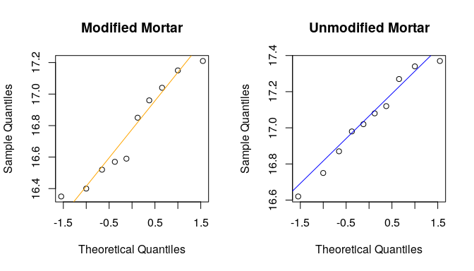

```r
op <- par(mfrow=c(1,2))
qqnorm(ModifiedMortar, main="Modified Mortar")
qqline(ModifiedMortar, col='orange')
qqnorm(UnmodifiedMortar, main="Unmodified Mortar")
qqline(UnmodifiedMortar, col='blue')
```

```r
par(op)
```

Visual inspection doesn’t suggest any strong violation of the assumption. Note that `par` is setting the graphical parameter `mfrow` so that we can plot two graphs next to each other. When setting with `par` the original value is returned and stored in `op`, which we then reset at the end.

```r
detach(Table2.1)  # Clean up since we're done with this data.
```

# Power and Sample Size

For power and sample size calculations we’ll use the `pwr` package (Champley et al. 2018). For the $t$-test we simply leave out the argument we want calculated. Recall that
$$d = \frac{|\mu_1 - \mu_2|}{\sigma}$$
so for the mortar experiment we’d want $d=2$, then if each group has 10 observations we find the power below.

```r
library(pwr)
pwr.t.test(n=10, d=2, sig.level=0.05, type='two.sample', alternative='two.sided')
#
#      Two-sample t test power calculation
#
#               n = 10
#               d = 2
#       sig.level = 0.05
#           power = 0.988179
#     alternative = two.sided
#
# NOTE: n is number in *each* group
```

Here, our power was 98.8%. How many observations would we have needed to get the power of our test to 90%?

```r
pwr.t.test(power=0.9, d=2, sig.level=0.05, type='two.sample', alternative='two.sided')
#
#      Two-sample t test power calculation
#
#               n = 6.386753
#               d = 2
#       sig.level = 0.05
#           power = 0.9
#     alternative = two.sided
#
# NOTE: n is number in *each* group
```

If we were planning the mortar experiment we’d want to make sure we had about 7 observations of each mortar to achieve approximately 90% power.

## Unequal Variance - Example 2.1

In Example 2.1 a study of the normalized fluorescence (after two hours) was undertaken for nerve tissue from 12 mice and muscle tissue from 12 mice. Note that our data is not paired. We wish to test
$$H_0: \mu_\text{Nerve} = \mu_\text{Muscle}
\quad\text{vs.}\quad
H_A: \mu_\text{Nerve} > \mu_\text{Muscle}~.$$

The data from this experiment is presented in Table 2.3.

| Observation | Nerve | Muscle |
| --- | --- | --- |
| 1 | 6625 | 3900 |
| 2 | 6000 | 3500 |
| 3 | 5450 | 3450 |
| 4 | 5200 | 3200 |
| 5 | 5175 | 2980 |
| 6 | 4900 | 2800 |
| 7 | 4750 | 2500 |
| 8 | 4500 | 2400 |
| 9 | 3985 | 2200 |
| 10 | 900 | 1200 |
| 11 | 450 | 1150 |
| 12 | 2800 | 1130 |

Summary statistics for the data are presented below.

```r
summary(Table2.3[,c('Nerve','Muscle')])
#      Nerve          Muscle
#  Min.   : 450   Min.   :1130
#  1st Qu.:3689   1st Qu.:1950
#  Median :4825   Median :2650
#  Mean   :4228   Mean   :2534
#  3rd Qu.:5262   3rd Qu.:3262
#  Max.   :6625   Max.   :3900
```

The summary statistics left out the standard deviations, which we can calculate below.

```r
c('Nerve'=sd(Table2.3$Nerve), 'Muscle'=sd(Table2.3$Muscle))
#     Nerve    Muscle
# 1917.9919  960.5061
```

Those estimates are strikingly different. Examining the normal probability plots we find a very distinct difference in slope, suggesting that the variances are unequal.

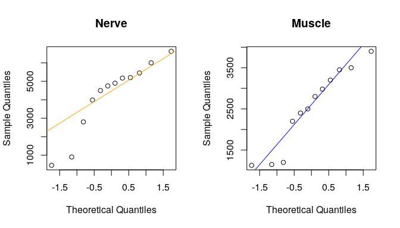

```r
op <- par(mfrow=c(1,2))
qqnorm(Table2.3$Nerve, main="Nerve")
qqline(Table2.3$Nerve, col='orange')
qqnorm(Table2.3$Muscle, main="Muscle")
qqline(Table2.3$Muscle, col='blue')
```

```r
par(op)
```

```r
df <- data.frame(
    'Flourescence'=c(Table2.3$Muscle, Table2.3$Nerve),
    'Tissue'=factor(c(rep('Muscle', 12), rep('Nerve', 12)))
)
t.test(Flourescence ~ Tissue, data=df, paired=FALSE, var.equal=FALSE, alternative='greater')
#
#   Welch Two Sample t-test
#
# data:  Flourescence by Tissue
# t = -2.7353, df = 16.191, p-value = 0.9927
# alternative hypothesis: true difference in means is greater than 0
# 95 percent confidence interval:
#  -2774.063       Inf
# sample estimates:
# mean in group Muscle  mean in group Nerve
#             2534.167             4227.917
```

# Paired Comparisons

In Section 2.5.1 the hardness testing experiment is introduced. In this experiment, the depth of two different tips in samples of metal is measured. Note that each tip was tested on the same piece of metal, so our data is paired. The data for this experiment is given in Table 2.6.

| Specimen | Tip1 | Tip2 |
| --- | --- | --- |
| 1 | 7 | 6 |
| 2 | 3 | 3 |
| 3 | 3 | 5 |
| 4 | 4 | 3 |
| 5 | 8 | 8 |
| 6 | 3 | 2 |
| 7 | 2 | 4 |
| 8 | 9 | 9 |
| 9 | 5 | 4 |
| 10 | 4 | 5 |

```r
df <- data.frame(
    'Depth'=c(Table2.6$Tip1, Table2.6$Tip2),
    'Tip'=factor(c(rep('Tip1', 10), rep('Tip2', 10)))
)
t.test(Depth ~ Tip, data=df, paired=TRUE)
#
#   Paired t-test
#
# data:  Depth by Tip
# t = -0.26414, df = 9, p-value = 0.7976
# alternative hypothesis: true difference in means is not equal to 0
# 95 percent confidence interval:
#  -0.9564389  0.7564389
# sample estimates:
# mean of the differences
#                    -0.1
```

With a $p$-value of 0.8 we certainly don’t have evidence to reject our null hypothesis that the means are equal.

# Notes

There are many other functions in R that handle a lot of the analysis we might want to do. A non-exhaustive list follows:

- `binom.test` - Exact binomial test.
- `chisq.test` - Pearson’s $\chi^2$-test for count data.
- `krustkal.test` - Kruskal-Wallis rank-sum test.
- `prop.test` - A one or two sample test of proportions.
- `quantile` - Get the empirical quantiles of a set of data.
- `shapiro.test` - Tests for normality of the data.
- `summary` - Produce a summary of data or other object.
- `t.test` - The two sample $t$-test.
- `table` - Tabulate data. Note that if you `summary` a table then a $\chi^2$ test of independence is performed.
- `var.test` - Conduct the two sample $F$-test for population variance
- `wilcox.test` - Test and construct confidence interval for the median.

# References

Champley, Stephane, Claus Ekstrom, Peter Dalgaard, Jeffrey Gill, Stephan Weibelzahl, Aditya Anandkumar, Clay Ford, Rovert Volcic, and Helios De Rosario. 2018. *Pwr: Basic Functions for Power Analysis*. https://cran.r-project.org/package=pwr.